# Weather file decomposition analysis: update 3

I’ve been doing a bit more digging on the data this week.

Just to recap, the I’ve tested lots of the DSY files with lots of buildings. I’ve been looking at where the internal temperature $\Delta T > 0$ (because this affects all of the CIBSE overheating criteria).

**However**, the times are the year where $\Delta T > 0$ are not the same for all buildings. I wanted to find out how this varied.

## How the buildings were set up

We used a simple building model and allowed some of the variables to change. These were:

|  | Name | Min. | Max |
| --- | --- | --- | --- |
| 3 | Floors | 1.00 | 2.0 |
| 4 | number_of_adiabatic_walls | 0.00 | 2.0 |
| 5 | Aspect_ratio | 0.50 | 1.0 |
| 6 | U-value_walls | 0.10 | 0.5 |
| 7 | U-value_roof | 0.10 | 0.5 |
| 8 | ACH | 1.00 | 6.0 |
| 9 | glazing_North | 0.00 | 0.9 |
| 10 | glazing_South | 0.00 | 0.9 |
| 11 | glazing_East | 0.00 | 0.9 |
| 12 | glazing_West | 0.00 | 0.9 |

[output cut: 13 more lines]

Using these ranges, I selected 30 building using a Latin Hypercube method (next time I run the simulation, I’m going to use more samples…)

## Results so far

Each building was run using each of the 42 of the DSY files (3 weather files at each of the 14 locations). The hours where $\Delta T$ is greater than 0 were counted.

Here’s the output of a 30 building Newcastle DSY2 shown in both a stacked and histogram format:

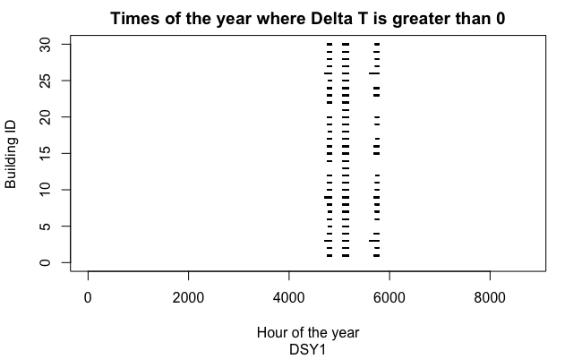

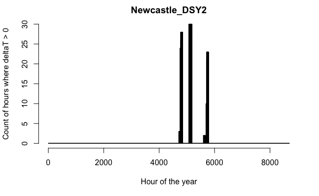

The results differ quite a bit for warmer locations like London, although there are commonalities across buildings:

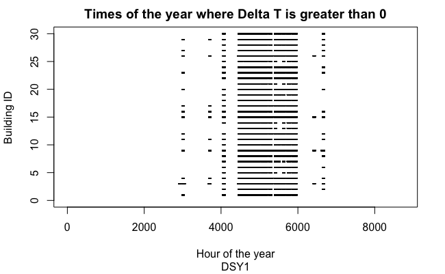

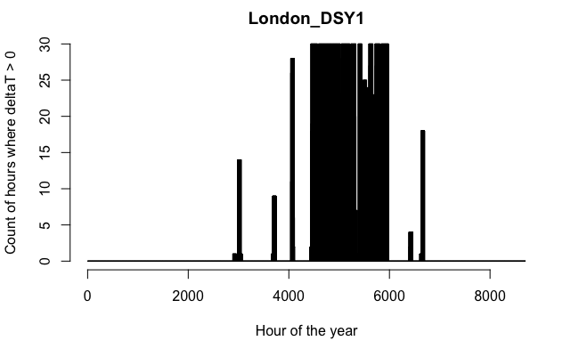

## Delta T doesn’t detect severity

As Matt rightly pointed out today, $\Delta T$ doesn’t affect severity. So next week I’ll be working on ways to do that. If you have any good ideas, you email me.